# LargeST traffic flow over OpenStreetMap roads

This example is an **offline reproduction bundle**: the `data/` folder contains the complete saved traffic snapshot (288 five-minute frames), downloaded OSM roads, water and place labels, and the source archive, tile checksums, dates and provenance of the downloads. Keep this folder, `osm-figures.R` and this R Markdown together. Install `bdynets`, `jsonlite`, `knitr` and `rmarkdown` once. Knitting requires no network, original HTML, HDF5 files, model fitting or browser execution.

```r
library(bdynets)
source("osm-figures.R")
stopifnot(file.exists(params$snapshot))
snapshot <- read_traffic_data(params$snapshot)
stopifnot(snapshot$source == "largest")
```

## Morning traffic in geographic context

The default is **08:00 on July 31, 2019** (one-based frame 97). Thin gray lines show downloaded OSM major roads from the zoom-9 basemap. Colored lines retain the original traffic display links, source quantile thresholds and directional offsets; these links are **not map-matched road segments or inferred network adjacency**. The background is a contemporary OSM extract, not a reconstruction of the road network in 2019. Both layers use Web Mercator. Labels are thinned for readability.

```r
frames <- largest_osm_figures(snapshot, time_index=params$time_index)
```

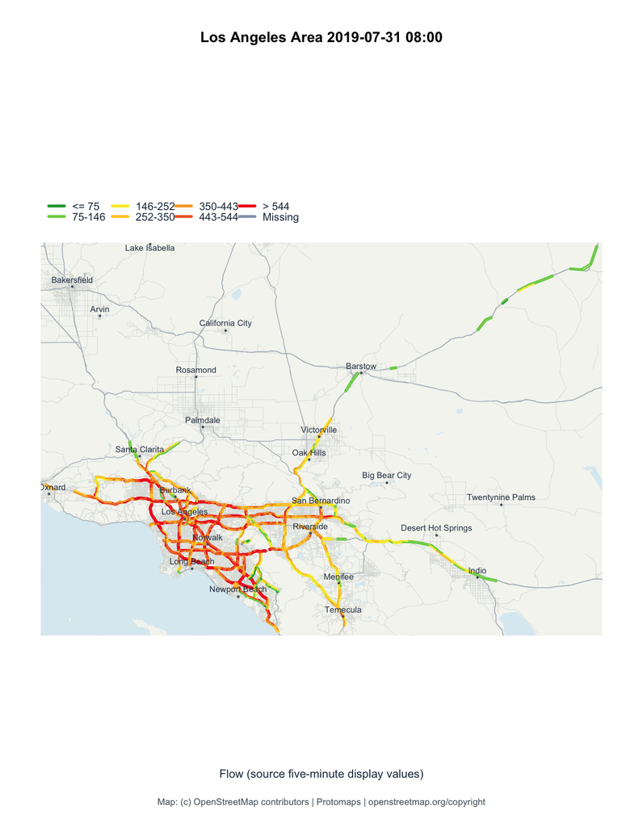

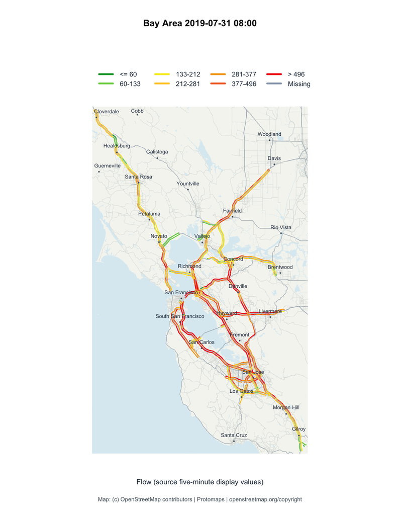

Each region uses its own saved quantile thresholds: the same color need not mean the same flow in the two regions. Missing flow is gray. Values retain the source visualization’s saved precision; display-link values are endpoint averages and should not be treated as independent sensor counts.

## Export figures and retain the selected data

This executable chunk creates a real relative directory, including parents, and checks that it is writable before opening graphics devices. Re-knitting replaces this example’s named exports. Change `output_dir` to preserve a run.

```r
largest_osm_figures(snapshot, time_index=params$time_index,
                    output_dir=params$output_dir)
list.files(params$output_dir)
```

```
## [1] "bay-area.pdf"        "bay-area.png"        "input-checksums.csv"
## [4] "los-angeles.pdf"     "los-angeles.png"     "selected-frames.rds"
## [7] "session-info.txt"
```

Exports include PDF, high-resolution PNG, selected frames as RDS, input checksums and session information. The full traffic time series and OSM-derived responses stay in `data/`, so other time frames can be reproduced offline.

```r
# Original viewer default: 16:10, one-based frame 195.
largest_osm_figures(snapshot, time_index=195L,
                    output_dir="output/largest-1610")
```

## Data provenance

Map data © [OpenStreetMap contributors](https://www.openstreetmap.org/copyright), available under ODbL 1.0. The cached display geometry comes from the October 12, 2026 [Protomaps build](https://docs.protomaps.com/basemaps/downloads), an OSM-derived basemap distributed as an ODbL Produced Work. Geometry is simplified at zoom 9 and split at tile boundaries; it is suitable for map context, not routing or raw OSM network analysis. Water and place labels are cached too. `download_osm.py` documents the one-time download and skips existing extracts; normal rendering never calls it. To refresh deliberately, archive the old OSM files and run the script with Python 3, `pmtiles`, `mapbox-vector-tile`, `requests` and internet access. Daily upstream archives may expire; the committed local extracts are the reproducible source for these figures.

```r
snapshot$provenance
```

```
## $file
## [1] "largest-visualization.json.gz"
##
## $md5
## [1] "4f63a05a91ce300afb32c7c87ab43a05"
##
## $source_html
## [1] "largest_la_bay_area_flow_2019_07_31.html"
##
## $source_sha256
## [1] "8da4eeb1058ab57bb32943dc7c87bf2bf668ba4c43ccf3d54867e6060760b60b"
##
## $representation
## [1] "saved HTML display precision; extracted without recalculation"
```

```r
lapply(list.files("data",pattern="osm-provenance.json$",full.names=TRUE),
       function(path) {
         p <- jsonlite::fromJSON(path)
         p[c("source_url", "build_date", "retrieved_utc", "zoom",
             "sha256_uncompressed", "attribution", "limitations")]
       })
```

```
## [[1]]
## [[1]]$source_url
## [1] "https://build.protomaps.com/20261012.pmtiles"
##
## [[1]]$build_date
## [1] "2026-10-12"
##
## [[1]]$retrieved_utc
## [1] "2026-10-15T13:23:00.885383+00:00"
##
## [[1]]$zoom
## [1] 9
##
## [[1]]$sha256_uncompressed
## [1] "853c5171688732dd72a43605a209724d1c9adbf00488f849119d3ed72ac1f3c7"
##
## [[1]]$attribution
## [1] "© OpenStreetMap contributors; Protomaps"
##
## [[1]]$limitations
## [1] "Generalized display geometry, clipped by vector tile boundaries. Not raw OSM ways or routing topology."
##
##
## [[2]]
## [[2]]$source_url
## [1] "https://build.protomaps.com/20261012.pmtiles"
##
## [[2]]$build_date
## [1] "2026-10-12"
##
## [[2]]$retrieved_utc
## [1] "2026-10-15T13:22:43.699980+00:00"
##
## [[2]]$zoom
## [1] 9
##
## [[2]]$sha256_uncompressed
## [1] "7461d0a3c80884667ff30284885bd0e47c5d26854b5840a530ad194900dc0ddc"
##
## [[2]]$attribution
## [1] "© OpenStreetMap contributors; Protomaps"
##
## [[2]]$limitations
## [1] "Generalized display geometry, clipped by vector tile boundaries. Not raw OSM ways or routing topology."
```

```r
lapply(snapshot$data$regions,function(region) unlist(region$breaks))
```

```
## $`Los Angeles Area`
## [1]  75 146 252 350 443 544
##
## $`Bay Area`
## [1]  60 133 212 281 377 496
```

[session information not shown]